# Introdução ao R - Sessão 1

Instalação, configuração e funcionamento básico do R e RStudio

Tiago Ferreira

Outubro 14, 2020

AGENDA | Funcionamento básico do R e Rstudio

**1. Vantagens e desvantagens do R e RStudio**  
**2. Obter e instalar o R e RStudio**  
**3. Primeira utilização do R & RStudio**  
**4. Comunicação básica com o R**  
**5. Sessão de trabalho, working directory, workspace e consola**  
**6. Acesso a ajuda**  
**7. Funções e pacotes**  
**8. EXERCÍCIO 1: Lotaria**

# 1. Introdução ao R e RStudio - Vantagens e desvantagens

O R é uma linguagem e ambiente computacional, que permite implementar técnicas de análise estatísticas e visualização. O R foi desenhado como ambiente de computação, possibilitando a integração com outras linguagens de computação, nomeadamente C, C++ e Fortran. É uma das mais populares aplicações de computação estatística e visualização de dados, apresentando um grande potencial e flexibilidade na produção de novas técnicas. Estas características fazem do R um veiculo preferencial para a investigação em métodos estatísticos.

O R deriva da linguagem de programação S, desenvolvida nos laboratórios Bell por Jonh Chambers e colegas (1988). O formato atual do R foi projetado por Robert Gentleman and Ross Ihaka do Statistics Department of the University of Auckland em 1997. Desde então, o R tem sido permanentemente melhorado, [sendo o resultam de um trabalho colaborativo ainda em curso](https://www.r-project.org/contributors.html).

A instalação base do R integra um conjunto de recursos que facilitam a criação, manipulação e análise de dados, bem como a apresentação desses dados em formato gráfico. Salientam-se funcionalidades ao nível da:

- Manipulação e armazenamento de dados
- Computação em matrizes e bases de dados
- Análise de dados
- Produção gráfica
- Programação e desenvolvimento de funções

As funcionalidades básicas do R são facilmente extensíveis através de pacotes criados por uma comunidade muito dinâmica de utilizadores e que estão disponíveis no repositório da CRAN [(Comprehensive R Archive Network)](https://www.r-project.org/) para download gratuito. O CRAN é uma coleção de sites com material para distribuição do R, extensões, documentação e ficheiros binários do R. O site principal do CRAN está alojado na Universidade de Viena sendo duplicado diariamente para muitos outros alojamentos espalhados por todo o mundo.

## Razões para usar o R

A utilização do [R tem aumentado muito nos últimos anos](https://stackoverflow.blog/2017/10/10/impressive-growth-r/) em resultado da melhoria da performance computacional e do aumento exponencial do volume de dados disponível. Áreas como a estatística, psicometria, econometria e machine learning têm impulsionado a produção e análise de dados. Por outro lado, novos métodos e procedimentos estatísticos são constantemente desenvolvidos por académicos. O R permite uma implementação rápida desses novos métodos, possibilitando a sua utilização disseminada. Atualmente, é frequente a publicação de um novo procedimento estatístico ser acompanhada pelo código R que permite operacionalizar esse novo procedimento.

[Existem várias razões para considerar começar a utilizar o R](https://www.r-bloggers.com/why-use-r-five-reasons/):

- É gratuíto
- Permite todo (ou quase todo) o tipo de análise de dados
- Implementa técnicas de análise de dados não disponíveis noutros softwares
- Implementa as técnicas de visualização de dados mais avançadas
- Possibilidade a importação de quase todos os formatos de dados
- Proporciona um ambiente ótimo de programação de novas técnicas estatísticas
- Compatível com a generalidade dos sistemas operativos

Se não pretender aprender a linguagem R, existem um conjunto de interfaces gráficos (GUIs - Graphic user interfaces) que permitem utizar o [R através do Point-and-click](https://www.r-bloggers.com/the-popularity-of-point-and-click-guis-for-r/), com a ajuda de menus e caixas de diálogo (e.g., o [rcommander](https://www.rcommander.com/)).

## Razões para usar o RStudio:

RStudio é um integrated development environment (IDE) que facilita (muito) o trabalho com o R:

- Permite produzir relatórios em formato publicável (sistema RMarkdown)
- Proporciona um suporte integrado para editar e executar código R
- Permite o acesso a várias funcionalidades do R através de um interface gráfico
- Permite criar e partilhar projetos
- [Incluí funcionalidades de apoio à programação](https://support.rstudio.com/hc/en-us/articles/200484448-Editing-and-Executing-Code);
- [e muito mais…](https://www.r-bloggers.com/top-6-reasons-you-need-to-be-using-rstudio/)

[figure not shown]

# 2. Obter e instalar o R e RStudio

1. Download R: http://cran.r-project.org/
2. Download RStudio: http://www.rstudio.org/  
   Ambas as aplicação são gratuitas e compatíveis com os principais OS:
- PC
- MAC
- Linux

**IMPORTANTE:**  
*Instalar primeiro o R e só depois o RStudio*

## Requisitos de hardware

Não existem especificações de hardware obrigatórias para a utilização do R. As condições de hardware necessárias dependem do volume de dados tratados e do tipo de análises conduzidas.  
Porque o R depende muito da RAM (Random Access Memory), é frequentemente recomendado que o computador tenha pelo menos 4 GB de RAM. Este valor deve ser um pouco maior em sistemas operativos MAC.

A avaliação da eficiência do hardware para utilizar o R deve considerar os seguintes pontos:

### Verificar a RAM do seu computador

```r
#1
install.packages("benchmarkme")
#2
library("benchmarkme")
#3
benchmarkme::get_ram()
```

A quantidade de RAM disponível é fundamental uma vez que o R grava todos os objetos nesta memória. Reduzida RAM pode limitar o tamanho de dados que podem ser analisados. Além disso, mesmo quando lidamos com bases de dados pequenas, as análises conduzidas podem produzir objetos que exigem muito espaço de armazenamento. Neste sentido, pode fazer sentido considerar ampliar a memória RAM do seu computador para 16GB ou até 32 GB.

### Verificar o tipo de disco do seu computador (HD vs SSD)

O tipo de disco não interfere na performance do R propriamente dita. No entanto, a existência de um disco SSD (mais rápido que um disco HD) faz com que a iniciação do R, bem como tarefas gerais de armazenamento, sejam feitas muito mais rapidamente.

### O sistema operativo: 32-bit ou 64-bit

O R pode ser instalado em duas versões: 32-bit ou 64-bit. Os sistemas operativos (SO) dos nosso computadores têm também estas duas versões. Idealmente tanto o R como o SO do nosso computador devem estar instalados a 64-bit. A utilização de versões de 32-bit traduz-se em significativas limitações na quantidade de RAM acessível ao R. Verifique a versão do R que está a utilizar através do seguinte comando:

```r
.Machine$sizeof.pointer # o resultado será 8 se a instalação de 64-bit estiver a correr
```

### O processador (CPU)

O processador é o responsável pela performance de todos os cálculos numéricos. Quanto mais rápido o processador do nosso computador mais rapidamente o R vai correr as nossas análises. A velocidade do nosso computador pode ser analisada e comparada com a performance de outros computadores recorrendo ao pacote benchmarkme.

```r
res <-  benchmark_std()  # analyse performance

plot(res) # compare the results to other users

upload_results(res) # Upload your benchmarks for future users
```

# 3. Primeira utilização do R & RStudio

## O Ambiente R

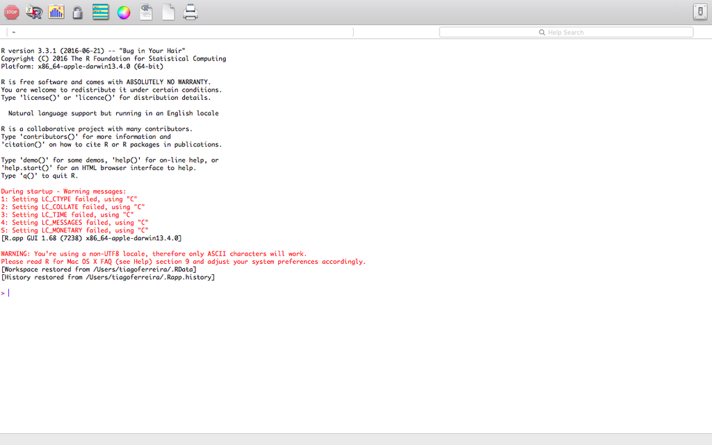

## O ambiente RStudio

[figure not shown]

### Tipos de painéis e ficheiros de RStudio

#### R Scripts e Markdown

Para criar um script no RStudio: File -> New File -> R Script  
Criado o novo script, no qual podemos inserir o código R.

Para criar um ficheiro R Markdown no RStudio: File -> New File -> R Markdown…  
Este ficheiro pode ser utilizado para elaborar relatórios em formatos html, pdf, ppt e doc, que pode sem exportados e depois partilhados.

#### Outros painéis no RSudio

- Environment: Visualizar e aceder aos diferentes objetos criados durante a sessão
- History: visualização do histórico das operações realizadas
- Communication: permite estabelecer ligações a bases de dados externas ao R
- Files: ficheiros existentes no work directory
- Plots: visualização de gráficos  
  Se o código R gerar um objeto gráfico, esse objeto pode ser visualizado e exportado no painel “plot”
- Packages: Visualizar e gerir pacotes
- Help: visualizar ficheiros de ajuda
- Viewer: visualização de outros objetos R

## Visão geral do funcionamento básico

R pode ser vista como uma grande calculadora com a capacidade de realizar todo o tipo de operações matemáticas. Vamos explorar um pouco esta calculadora. Para isso vamos abrir um novo script e executar as seguintes linhas de código. Para correr o código num script, selecionamos esse código e clicamos em **Run**. Para o mesmo efeito, podemos usar o atalho **ctrl + enter** se estivermos a trabalhar em windows ou **cmd + enter** se estivermos num mac. **#** pode ser usado quando pretendemos acrescentar comentários à nossa sintaxe. O R vai ignorar tudo o que está após este sinal.

```r
#1
print("Hello World!")  # displays "Hello World"
```

```
## [1] "Hello World!"
```

```r
# in RStudio press "cmd/ctrl-enter" to execute code

#2
1:100  # displays numbers from 1 to 100
```

```
##   [1]   1   2   3   4   5   6   7   8   9  10  11  12  13  14  15  16  17  18
##  [19]  19  20  21  22  23  24  25  26  27  28  29  30  31  32  33  34  35  36
##  [37]  37  38  39  40  41  42  43  44  45  46  47  48  49  50  51  52  53  54
##  [55]  55  56  57  58  59  60  61  62  63  64  65  66  67  68  69  70  71  72
##  [73]  73  74  75  76  77  78  79  80  81  82  83  84  85  86  87  88  89  90
##  [91]  91  92  93  94  95  96  97  98  99 100
```

```r
#3
67 + 33  # basic math operations
```

```
## [1] 100
```

```r
#4
89.41 * 415.56
```

```
## [1] 37155.22
```

```r
#5
sqrt(25) # square root
```

```
## [1] 5
```

```r
#6
x <- 10 * 100 # saves results

#7
0.5 * x # half of x
```

```
## [1] 500
```

```r
#8
x <- 2
log(x) # natural logarithm of x
```

```
## [1] 0.6931472
```

```r
#9
log10(x) # base 1o logarithm of x
```

```
## [1] 0.30103
```

```r
#10
log2(x) # base 2 logarithm of x
```

```
## [1] 1
```

```r
# ou
log(2, base=2) # OR: base 2 logarithm of x
```

```
## [1] 1
```

```r
#11
x <- 5.5 * 3; x  # ; can be used to execute more than one code at once
```

```
## [1] 16.5
```

Para além de operações matemáticas, podemos usar o R para criar estruturas de dados complexas, bem como analisar e visualizar esses dados.

```r
#1
ID <- (1:4)
#2
name <- c("Ana", "Manuel", "Afonso", "Maria")
#3
age <-  c(20,24,21,40)
#4
sex <- factor(c("female","male","male","female"),
              levels=c("male", "female"))
#5
rbaselevel <- c(15,35,45,20)# base level in a scale from 1 to 100

#6
rmotivation <- c(60,90,100,70)# motivation level in a scale from 1 to 100

#7
rintro <- data.frame(ID, name, age, sex, rbaselevel,rmotivation)
rintro
```

```
##   ID   name age    sex rbaselevel rmotivation
## 1  1    Ana  20 female         15          60
## 2  2 Manuel  24   male         35          90
## 3  3 Afonso  21   male         45         100
## 4  4  Maria  40 female         20          70
```

```r
#8
str(rintro)
```

```
## 'data.frame':    4 obs. of  6 variables:
##  $ ID         : int  1 2 3 4
##  $ name       : chr  "Ana" "Manuel" "Afonso" "Maria"
##  $ age        : num  20 24 21 40
##  $ sex        : Factor w/ 2 levels "male","female": 2 1 1 2
##  $ rbaselevel : num  15 35 45 20
##  $ rmotivation: num  60 90 100 70
```

```r
#9
rintro$name
```

```
## [1] "Ana"    "Manuel" "Afonso" "Maria"
```

```r
#10
mean(rintro$rbaselevel)
```

```
## [1] 28.75
```

```r
#11
summary(rintro)
```

```
##        ID           name                age            sex      rbaselevel
##  Min.   :1.00   Length:4           Min.   :20.00   male  :2   Min.   :15.00
##  1st Qu.:1.75   Class :character   1st Qu.:20.75   female:2   1st Qu.:18.75
##  Median :2.50   Mode  :character   Median :22.50              Median :27.50
##  Mean   :2.50                      Mean   :26.25              Mean   :28.75
##  3rd Qu.:3.25                      3rd Qu.:28.00              3rd Qu.:37.50
##  Max.   :4.00                      Max.   :40.00              Max.   :45.00
##   rmotivation
##  Min.   : 60.0
##  1st Qu.: 67.5
##  Median : 80.0
##  Mean   : 80.0
##  3rd Qu.: 92.5
##  Max.   :100.0
```

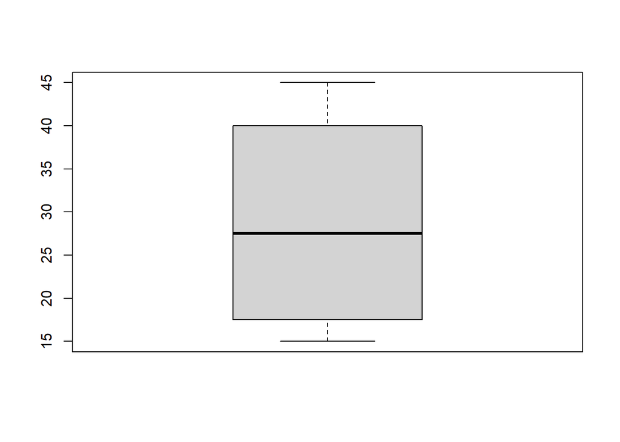

```r
boxplot(rintro$rbaselevel)
```

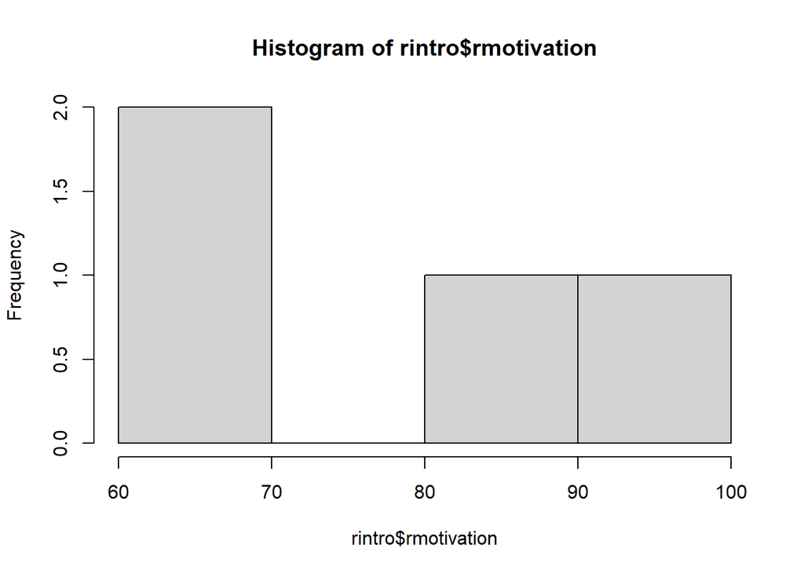

```r
hist(rintro$rmotivation)
```

# 4. Comunicação básica com o R

A interação com o R é feita através de uma linguagem de programação, a que habitualmente chamamos de sintaxe. Na base desta linguagem de programação estão um conjunto de operadores, que podem ir desde operadores matemáticos simples até funções complexas. Os operadores mais simples podem ser aritméticos, relacionais e lógicos. Na verdade, este operadores são funções simples, que normalmente não precisam de mais de dois argumentos para realizar um determinado procedimento.

## Operadores aritméticos

```r
6 + 2 # addition
```

```
## [1] 8
```

```r
6 - 2 # subtraction
```

```
## [1] 4
```

```r
6 * 2 # multiplication
```

```
## [1] 12
```

```r
6 / 2 # division
```

```
## [1] 3
```

```r
6^2 # exponentiation
```

```
## [1] 36
```

```r
# OR
6**2
```

```
## [1] 36
```

```r
6 %/% 2 # integer division
```

```
## [1] 3
```

## Operadores relacionais

Estes operadores servem para comparar valores.

```r
6 < 2 # less than
```

```
## [1] FALSE
```

```r
6 <= 2 # less than or equal to
```

```
## [1] FALSE
```

```r
6 > 2 # greater than
```

```
## [1] TRUE
```

```r
6 >= 2 # greater than or equal to
```

```
## [1] TRUE
```

```r
6 == 2  # exactly equal to
```

```
## [1] FALSE
```

```r
6 !=    2 # not equal to
```

```
## [1] TRUE
```

## Operadores Lógicos

Estes operadores servem para realizar operações booleanas (Verdadeiro ou Falso):

```r
!6  # Not 6
```

```
## [1] FALSE
```

```r
6 | 2 # 6 OR 2
```

```
## [1] TRUE
```

```r
6 & 2   # 6 AND 2
```

```
## [1] TRUE
```

## O operador de atribuição

Uma das grandes vantagens do R é a capacidade de alocar diferentes estruturas de dados a objetos que podem ser analisados e manipulados. No R, um objeto é definido como qualquer tipo de informação que possa ser alocada a um valor. Esta alocação é feita através do operador de atribuição (“<-”, assignment). Os objetos criados são armazenados na memória durante a sessão de trabalho.

```r
#1. Assigns characters to objects "a" and "b"
a <- "Hi! How are you?"
b <- "Welcome to your R session!"

#2. Prints objects
print(c(a, b))
```

```
## [1] "Hi! How are you?"           "Welcome to your R session!"
```

Falaremos sobre funções com mais detalhe já de seguida. Adiantamos, no entanto, que as funções são tipos especiais de objetos do R definida por um conjunto de expressões que, quando executadas sequencialmente, permitem realizar um procedimento específico. Uma função incluí geralmente um conjunto de argumentos, que são definidos pelo utilizado dentro de parênteses. Estes argumentos são o input que a função necessita para ser executada. No caso anterior da função **print()**, os argumento é **c(a,b)**. Este argumento consiste no resultado da função **c()** aplicada aos argumentos **a** e **b**.

```r
#3. Assigns number 10 to object x1
x1 <- 10

#4. Presents x1
x1
```

```
## [1] 10
```

```r
#5. Assigns integers from 1 to 10 to object x2
x2 <- 1:10

#6. Presents and Plots x2
x2
```

```
##  [1]  1  2  3  4  5  6  7  8  9 10
```

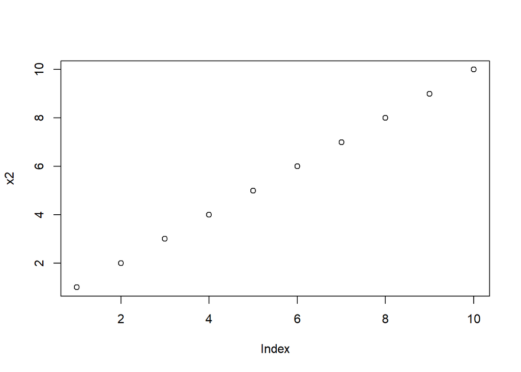

```r
plot(x2)
```

```r
#7. Assigns to x3 the exponentiation of x2
x3 <- x2^4

#8. Presents and plots x3
x3
```

```
##  [1]     1    16    81   256   625  1296  2401  4096  6561 10000
```

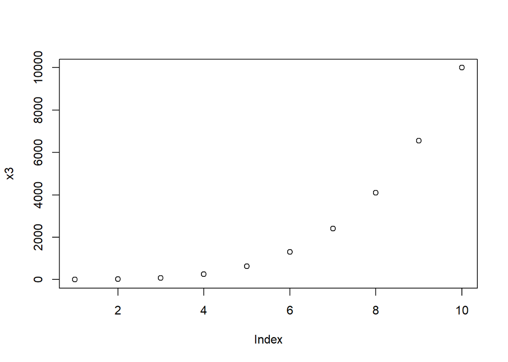

```r
plot(x3)
```

```r
#9. Assigns to x4 the product between each element of x2 with x1
x4 <- x2*x1

#10. Presents and plots x4
x4
```

```
##  [1]  10  20  30  40  50  60  70  80  90 100
```

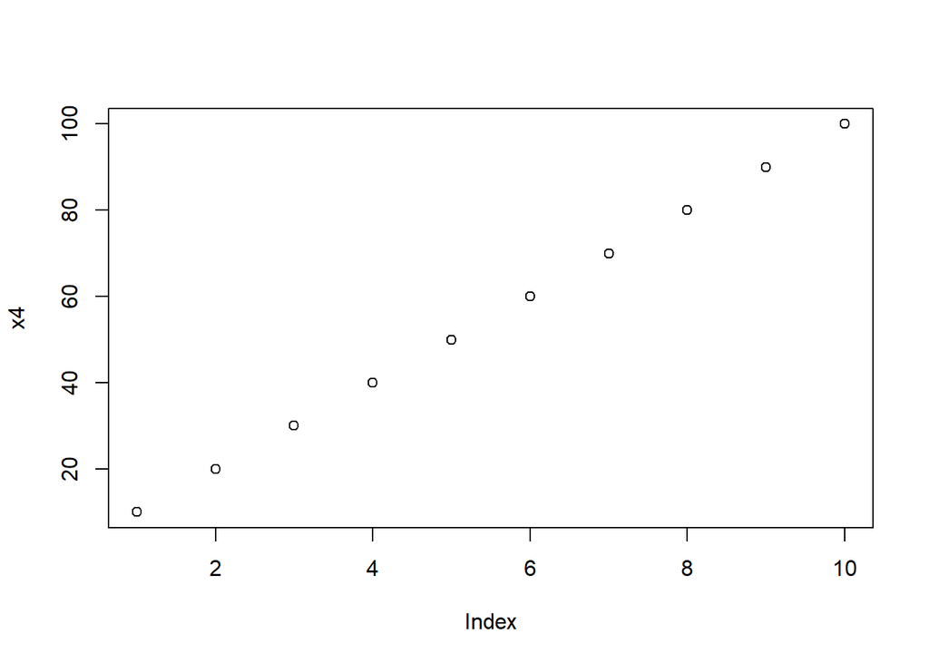

```r
plot(x4) # plotting x4
```

```r
#11. Which elements of x3 are smaller than x4?
x5 <- x3 < x4
x5
```

```
##  [1]  TRUE  TRUE FALSE FALSE FALSE FALSE FALSE FALSE FALSE FALSE
```

```r
#12. Which exact values of x3 are smaller than x4?
x3[x5]
```

```
## [1]  1 16
```

```r
x3
```

```
##  [1]     1    16    81   256   625  1296  2401  4096  6561 10000
```

```r
x4
```

```
##  [1]  10  20  30  40  50  60  70  80  90 100
```

#### “Google’s R Style Guide”

```r
browseURL("https://google.github.io/styleguide/Rguide.xml")
```

# 5. Sessão de trabalho, working directory, workspace e consola

O workspace (painel Environment no RStudio) é o local onde são guardados todos os objetos criados pelo utilizador durante a sessão de trabalho. No final de cada sessão de trabalho é possível guardar uma imagem do workspace, que será automaticamente carregada no início de uma nova sessão.  
O diretório de trabalho (working directory) consiste na localização onde o R, por defeito, irá ler e salvar ficheiros. Para percebe qual o working directory atual podemos usar a função getwd(). Para alterar o working directory aplica-se a função setwd(). Se for necessário importar para o R algum ficheiro que não está localizado no diretório de trabalho atual, deverá ser especificado o caminho completo para a localização do ficheiro em causa. Este caminho deverá sempre ser redigido dentro de aspas.  
De seguida, apresentam-se algumas das funções mais utilizadas na gestão da sessão de trabalho, do worspace e do working directory.

## Informação sobre a sessão de trabalho

```r
#1
sessionInfo() # print information about R version, the OS and attached or loaded packages.

#2
Sys.Date() # prints the system's current date

#3
getRversion() # prints the R version

#4
search() # prints the loaded packages

#5
help(options) # provides information about available options (e.g., max.print, digites, show.error.messages)

#6
options() # prints the current options

#7
history(#) displays your last # commands (def. = 25)

#8
savehistory("myfile") # saves the commands history to myfile (def. = .Rhistory)

#9
q() # quits R session
```

## Informação e gestão do working directory

```r
#1
getwd() # Lists the current work

#2
setwd("C:/Users/tiago/Desktop") # change the current wd to desktop

#3
dir.create() # creates a new wd
```

## Informação e gestão do workspace

```r
#1
ls() # lists objects available in workspace

#2
save.image("myfile") # saves the workspace to myfile (def. = .RData)

#3
save(objectlist, file = "myfile.RData") # saves a list of objects to a file

#4
load("myfile") # loads a workspace into the current session

#5
rm(x)  # Removes x from workspace

#6
rm(a, b)  # Removes a and b from workspace

#7
rm(list = ls())  # Removes all objects from workspace
```

## Limpeza da consola

```r
cat("\014") # cleans console
# OR
shell("cls") # shell("clear") if Linux or Mac.
# OR
# shortcut Ctrl + l
```

# 6. Acesso a ajuda

O R disponibiliza um extenso suporte à sua utilização. Será pois importante conhecer e perceber a forma de aceder a essas ajudas. O R possui um sistema integrado de ajuda que fornece detalhes, referências e exemplos de todas as funções instaladas. Poderá aceder a este sistema de ajuda através das seguintes funções genéricas.

```r
#1
help.start() # general help

#2
help("summary") # help on the function "summary" (quotation marks are optional)
# OR
?summary

#3
help.search("summary") # searches the help system using the keyword "summary"
# OR
??summary

#4
apropos("summary", mode="function") # Lists all available functions with "summary" in their names

#5
example("summary") # provides examples of the summary function (quotation marks are optional)

#6
help.start() # opens a browser window with access to introductory and advanced manuals, FAQs and reference materials

#7
RSiteSearch("summary") # searches for the string "summary" in the online help manuals and archived mailing lists
```

Para além de toda a ajuda disponibilizada na instalação base do R, os utilizadores de R formam frequentemente comunidades online muito ativas, com fóruns de discussão acerca dos mais diversos tópicos. Qualquer questão acerca da utilização do R é rapidamente respondida por utilizadores avançados. Alguns exemplos:

- https://stackoverflow.com/questions/3375808/learning-r-where-does-one-start
- https://www.r-bloggers.com/statistics-forum/

# 7. Funções e pacotes

## Funções R

As funções são um tipo de objeto específicos do R. Este objetos permitem realizar procedimentos estatísticos complexos pela execução sequencial de linhas de código mais simples. De seguida, apresentam-se dois exemplos muito simples que ilustram a importância das funções na programação R.

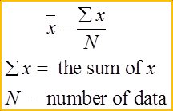

```r
#1
a <- c(9, 2, 5, 4, 12, 7, 8, 11, 9, 3, 7, 4, 12, 5, 4, 10, 9, 6, 9, 4)

#2
sum(a)
```

```
## [1] 140
```

```r
length(a)
```

```
## [1] 20
```

```r
sum(a)/length(a)
```

```
## [1] 7
```

```r
#3
mean <- sum(a)/length(a)

# OR simply use a built in function
mean(a)
```

```
## [1] 7
```

```r
#4
a <- c(9, 2, 5, 4, 12, 7, 8, 11, 9, 3, 7, 4, 12, 5, 4, 10, 9, 6, 9, 4)

#5
mean(a) # OR sum(a)/length(a)
```

```
## [1] 7
```

```r
a-mean(a)^2
```

```
##  [1] -40 -47 -44 -45 -37 -42 -41 -38 -40 -46 -42 -45 -37 -44 -45 -39 -40 -43 -40
## [20] -45
```

```r
sum((a-mean(a))^2)
```

```
## [1] 178
```

```r
1/(length(a)-1)
```

```
## [1] 0.05263158
```

```r
1/(length(a)-1)*sum((a-mean(a))^2)
```

```
## [1] 9.368421
```

```r
sqrt(1/(length(a)-1)*sum((a-mean(a))^2))
```

```
## [1] 3.060788
```

```r
#6

sd_user <- function(a) {
  sqrt(1/(length(a)-1)*sum((a-mean(a))^2))
} # Creating user function for SD

sd_user(a)
```

```
## [1] 3.060788
```

```r
# OR use R base functions
sd(a)
```

```
## [1] 3.060788
```

## Pacotes R - Instalar, carregar, atualizar, descarregar e desinstalar

Um pacote R consiste numa coleção de funções, dados e código compilado, organizados num formato bem definido. Atualmente, existe um grande número de pacotes R. Este pacotes estão alojados no CRAN e podem ser descarregados gratuitamente. Após download, os pacotes ficam guardados no nosso computador, numa localização denominada de *library*.

```r
#1
browseURL("http://cran.r-project.org/web/views/")  # "Comprehensive R Archive Network" (CRAN) webpage

#2
browseURL("http://cran.stat.ucla.edu/web/packages/available_packages_by_name.html") # available packages alphabetically ordered

#3
browseURL("http://crantastic.org/") # web community dedicated to the dissemination of R packages

#4
library()  # lists installed packages

#5
search()   # lists loaded packages

#6
packageVersion("psych") # check package version

#7
citation("psych") # package citation
```

## Instalar pacotes

Existem várias formas de instalar pacotes no RStudio

- Opção **point & click** no RStudio: Tools > Install Packages…
- Código R, que pode ser gravado e executado sempre que iniciar sessão

```r
#1
install.packages("ggplot2")  # Download package
?install.packages
```

## Carregar pacotes

```r
#2
library(Hmisc)  # loading packages
# OR
require(Hmisc)  # loading packages

#3
help(package="Hmisc")
```

NOTA: na utilização diária do R não existem diferenças entre library() e require() - a segunda é normalmente utilizada dentro de funções uma vez que permite continuar a executar a função mesmo que o pacote em questão não seja encontrado; a library() não continua a execução da função, sendo emitido uma mensagem de erro.

#8. EXERCÍCIO 1: Lotaria

Ver ficheiro **DRPMBE_Exerc1.html**